# Clase7_py_inter

## Curso de introducción a la programación con Python

**Autor: Luis Fernando Apáez Álvarez**  
-Curso PyM-  
Clase 6: Uniones (parte II)  
Fecha: 12 de diciembre del 2022

## Contenido

- Tipos de relaciones
  - Uniendo múltiples dataframes
  - Análisis
- Tipos de uniones
  - Unión izquierda y derecha
  - Unión externa
  - Uniendo una tabla con ella misma
  - Exportando dataframe a csv

Recordemos que en la clase pasada indagamos un poco sobre operaciones con conjuntos y su representación visual mediante los diagramas de Venn. Asimismo, indagamos en el tipo de unión denominada como *unión interna*, la cual, si vemos a los dataframes como conjuntos, no es más que la intersección de conjuntos.

Así, para iniciar esta clase:

```python
# importaciones necesarias
import matplotlib.pyplot as plt
from matplotlib_venn import venn2
import pandas as pd
import numpy as np
from faker import Faker

# Libreria para no ver las advertencias en la salida
import warnings
warnings.filterwarnings('ignore')

# Instanciamos
fake = Faker()
```

Luego definimos los dataframes con los que trabajaremos:

```python
# Creamos valores para asignar ids
ID = [i for i in range(1, 1001)]
# creamos 1000 nombres
nombres = [fake.name() + ' ' + fake.last_name() for i in range(1000)]
# 1000 correos electronicos
correos = [fake.email() for i in range(1000)]
# 1000 edades
edades = [fake.random_int(18, 80) for i in range(1000)]
# Creamos un diccionario con la info anterior
dict_info = {'ID': ID, 'Nombre': nombres, 'Edad': edades, 'Correo': correos}
# Creamos el dataframe
df_empleados = pd.DataFrame(dict_info)
# 1000 salarios
salarios = [np.random.rand() * 10000 for i in range(1000)]
# 1000 correos electronicos
correos = [fake.email() for i in range(1000)]
# Creamos un diccionario con el salario y el ID
dict_info = {'ID': ID, 'Salario': salarios, 'Correo': correos}
# Creamos el dataframe
df_salario = pd.DataFrame(dict_info)
# Empleados nuevos
emp1 = {'ID': 1001, 'Nombre': 'Diana Smith', 'Edad': 27, 'Correo': 'diana27182@edu.com'}
emp2 = {'ID': 1002, 'Nombre': 'Luka Ldresh', 'Edad': 20, 'Correo': 'lukaecdf@gmail.com'}
# Los agregamos al dataframe
df_empleados = df_empleados.append(emp1, ignore_index=True)
df_empleados = df_empleados.append(emp2, ignore_index=True)
```

Realizamos una unión interna:

```python
# realizamos la union interna y cambiamos los sufijos:
df_union_interna = df_empleados.merge(df_salario, on='ID',
                                     suffixes=('_personal', '_compañia'))
# veamos
df_union_interna.head()
```

|  | ID | Nombre | Edad | Correo_personal | Salario | Correo_compañia |
| --- | --- | --- | --- | --- | --- | --- |
| 0 | 1 | Mark Rodriguez Park | 66 | listephanie@example.net | 2815.715914 | bmora@example.com |
| 1 | 2 | Maria Patrick Foley | 58 | annawright@example.net | 8071.241496 | sandrathompson@example.org |
| 2 | 3 | Olivia Boyle King | 18 | alexander11@example.org | 1406.213853 | gibsonkevin@example.net |
| 3 | 4 | Kent Lloyd Thomas | 72 | rroberts@example.org | 8799.843576 | iharris@example.net |
| 4 | 5 | Connie Villa Meyer | 28 | micheal66@example.org | 3627.843246 | qreynolds@example.com |

### Tipos de relaciones

Tenemos distitos tipos de relaciones a la hora de unir dataframes. Para explicar dichos tipos supongamos que queremos unir dos dataframes (digamos $df_{1}$ y $df_{2}$), luego:

- Relación uno a uno: indica que a cada fila del $df_{1}$ le corresponde una única fila del $df_{2}$ y viceversa. Por ejemplo, para la unión interna que realizamos para los dataframes `df_empleados` y `df_salario` tenemos que la relación uno a uno pues a cada fila le corresponde una única fila y viceversa.
- Relación uno a muchos: indica que a cada fila del $df_{1}$ le coresponderá más de una fila del $df_{2}$. Por ejemplo, si consideraremos que a cada persona le corresponden dos correos electrónico, tenemos que la relación descrita sería de uno a muchos.
- Relación muchos a uno: es análoga a la anterior.
- Relación muchos a muchos: indica que a cada fila del dataframe $df_{1}$ le corresponden muchas filas del dataframe $df_{2}$ y viceversa, es decir, a cada fila del dataframe $df_{2}$ le corresponden muchas filas del dataframe $df_{1}$. Por ejemplo, si consideramos que cada persona tiene asociadas varias cuentas de banco con diferentes bancos tenemos una relación uno a muchos, pero además podemos considerar que un banco tiene cuentas de banco de muchas personas.

Veamos un ejemplo de relación uno a muchos, para ello:

```python
# Creamos un dataframe vacio con dos columnas
df_correos = pd.DataFrame({'ID': [], 'Correo': []})
df_correos
```

|  | ID | Correo |
| --- | --- | --- |

Posteriormente colocaremos la información del dataframe anterior a partir de la información dle dataframe `df_unio_interna` como sigue

```python
# Recorremos todas las filas de df_union_interna
for i in range(df_union_interna.shape[0]):
    # Creamos una fila nueva para el primer correo de
    # la persona
    new_row1 = {'ID': df_union_interna.iloc[i][0],
               'Correo': df_union_interna.iloc[i][3]}
    # Creamos una fila nueva para el segundo correo de
    # la persona
    new_row2 = {'ID': df_union_interna.iloc[i][0],
               'Correo': df_union_interna.iloc[i][5]}
    # Agregamos las filas nuevas al dataframe
    df_correos = df_correos.append([new_row1, new_row2], ignore_index=True)
# Vemos el dataframe resultante
df_correos
```

|  | ID | Correo |
| --- | --- | --- |
| 0 | 1.0 | listephanie@example.net |
| 1 | 1.0 | bmora@example.com |
| 2 | 2.0 | annawright@example.net |
| 3 | 2.0 | sandrathompson@example.org |
| 4 | 3.0 | alexander11@example.org |
| ... | ... | ... |
| 1995 | 998.0 | clarkcharles@example.net |
| 1996 | 999.0 | ejohnson@example.org |
| 1997 | 999.0 | jsmith@example.net |
| 1998 | 1000.0 | emilysantos@example.net |
| 1999 | 1000.0 | perkinsmonica@example.net |

2000 rows × 2 columns

```python
# Vemos que el tipo de dato de la columna ID es float64
print(df_correos['ID'].dtype)
```

```
float64
```

```python
# Cambiamos a int64 con la funcion astype():
df_correos['ID'] = df_correos['ID'].astype('int64')
print(df_correos['ID'].dtype)
```

```
int64
```

```python
df_correos.head()
```

|  | ID | Correo |
| --- | --- | --- |
| 0 | 1 | listephanie@example.net |
| 1 | 1 | bmora@example.com |
| 2 | 2 | annawright@example.net |
| 3 | 2 | sandrathompson@example.org |
| 4 | 3 | alexander11@example.org |

tenemos entonces que a cada persona (o ID) le corresponden dos correos, de modo que la relación qye tenemos es de uno a muchos. Lo que haremos ahora será llevar a cabo una unión interna entre los dataframes `df_empleados` y `df_correos`:

```python
# Antes de ello:
print(df_empleados.shape)
print(df_correos.shape)
```

```
(1002, 4)
(2000, 2)
```

```python
# notemos que el dataframe tiene una columna de correo
df_empleados.head()
```

|  | ID | Nombre | Edad | Correo |
| --- | --- | --- | --- | --- |
| 0 | 1 | Mark Rodriguez Park | 66 | listephanie@example.net |
| 1 | 2 | Maria Patrick Foley | 58 | annawright@example.net |
| 2 | 3 | Olivia Boyle King | 18 | alexander11@example.org |
| 3 | 4 | Kent Lloyd Thomas | 72 | rroberts@example.org |
| 4 | 5 | Connie Villa Meyer | 28 | micheal66@example.org |

```python
# Union interna:
#                    no consideramos la columna correo
#                    del primer dataframe
df_union_interna_2 = df_empleados.drop('Correo', axis=1).merge(df_correos, on='ID')
df_union_interna_2
```

|  | ID | Nombre | Edad | Correo |
| --- | --- | --- | --- | --- |
| 0 | 1 | Mark Rodriguez Park | 66 | listephanie@example.net |
| 1 | 1 | Mark Rodriguez Park | 66 | bmora@example.com |
| 2 | 2 | Maria Patrick Foley | 58 | annawright@example.net |
| 3 | 2 | Maria Patrick Foley | 58 | sandrathompson@example.org |
| 4 | 3 | Olivia Boyle King | 18 | alexander11@example.org |
| ... | ... | ... | ... | ... |
| 1995 | 998 | Todd Jenkins Anderson | 28 | clarkcharles@example.net |
| 1996 | 999 | Kimberly Mitchell Long | 65 | ejohnson@example.org |
| 1997 | 999 | Kimberly Mitchell Long | 65 | jsmith@example.net |
| 1998 | 1000 | Andrea Carson Liu | 48 | emilysantos@example.net |
| 1999 | 1000 | Andrea Carson Liu | 48 | perkinsmonica@example.net |

2000 rows × 4 columns

```python
df_union_interna_2.shape
```

[output not shown]

Notemos que hasta ahora hemos estado uniendo dataframes a partir de una sola columna, pero en realidad podemos realizar uniones a partir de más de una columna cuando sea necesario. Del ejemplo con el cual hemos estado trabajando hemos colocado `on='ID'` para especificar la columna que relaciona a los dataframes, luego, en caso de querer colocar más de una columna que relaciones a los dataframes que queremos unir, tendremos que colocar `on=['col1', 'col2', ...]`.

#### Uniendo múltiples dataframes

Para ver un ejemplo agreguemos una columna nueva al dataframe `df_empleados`:

```python
import random

# Creamos una lista con los departamentos de la
# compagnia
dep = ['Seguridad', 'Oficina', 'Almacen', 'Limpieza', 'Comedor', 'Transporte']

# podemos tomar de manera aleatoria un elemento de una lista:
random.choice(dep)
```

```
'Limpieza'
```

Luego, agregamos la columna nueva:

```python
df_empleados['Dep'] = [random.choice(dep) for i in range(df_empleados.shape[0])]
df_empleados.head()
```

|  | ID | Nombre | Edad | Correo | Dep |
| --- | --- | --- | --- | --- | --- |
| 0 | 1 | Mark Rodriguez Park | 66 | listephanie@example.net | Transporte |
| 1 | 2 | Maria Patrick Foley | 58 | annawright@example.net | Transporte |
| 2 | 3 | Olivia Boyle King | 18 | alexander11@example.org | Oficina |
| 3 | 4 | Kent Lloyd Thomas | 72 | rroberts@example.org | Comedor |
| 4 | 5 | Connie Villa Meyer | 28 | micheal66@example.org | Transporte |

Asimismo, crearemos un dataframe con los departamentos y el salario mínimo que manejan.

```python
dep
```

```
['Seguridad', 'Oficina', 'Almacen', 'Limpieza', 'Comedor', 'Transporte']
```

```python
sal_min = [8000, 8000, 7000, 6500, 6500, 7000]

# Creamos el dataframe
df_dep = pd.DataFrame({'Dep': dep, 'Salario_min': sal_min})
df_dep
```

|  | Dep | Salario_min |
| --- | --- | --- |
| 0 | Seguridad | 8000 |
| 1 | Oficina | 8000 |
| 2 | Almacen | 7000 |
| 3 | Limpieza | 6500 |
| 4 | Comedor | 6500 |
| 5 | Transporte | 7000 |

```python
# Primera union
df_union_interna_3 = df_empleados.merge(df_salario, on='ID',
                                        # cambiamos los sufijos
                                        suffixes=('_personal', '_compañia'))\
# Segunda union
                                 .merge(df_dep, on='Dep')
df_union_interna_3
```

|  | ID | Nombre | Edad | Correo_personal | Dep | Salario | Correo_compañia | Salario_min |
| --- | --- | --- | --- | --- | --- | --- | --- | --- |
| 0 | 1 | Mark Rodriguez Park | 66 | listephanie@example.net | Transporte | 2815.715914 | bmora@example.com | 7000 |
| 1 | 2 | Maria Patrick Foley | 58 | annawright@example.net | Transporte | 8071.241496 | sandrathompson@example.org | 7000 |
| 2 | 5 | Connie Villa Meyer | 28 | micheal66@example.org | Transporte | 3627.843246 | qreynolds@example.com | 7000 |
| 3 | 22 | Mary Payne Johnson | 18 | rdiaz@example.com | Transporte | 1575.459446 | warellano@example.net | 7000 |
| 4 | 36 | Michael Owens Burns | 27 | ypowell@example.net | Transporte | 5883.722804 | dsnyder@example.net | 7000 |
| ... | ... | ... | ... | ... | ... | ... | ... | ... |
| 995 | 964 | Robert Sandoval Powell | 24 | fcoleman@example.org | Almacen | 7072.541551 | thomasscott@example.com | 7000 |
| 996 | 972 | Maria Ortiz Schmidt | 80 | hluna@example.org | Almacen | 4497.752108 | jennifermoreno@example.com | 7000 |
| 997 | 990 | Jordan Jackson Higgins | 56 | lewisstephen@example.net | Almacen | 3609.770774 | thomasjames@example.net | 7000 |
| 998 | 992 | Sara Rodgers Mitchell | 60 | xkrause@example.com | Almacen | 6099.027649 | morrissean@example.net | 7000 |
| 999 | 998 | Todd Jenkins Anderson | 28 | lisaknight@example.com | Almacen | 2928.811436 | clarkcharles@example.net | 7000 |

1000 rows × 8 columns

Vemos que los salarios están muy por debajo de los salarios mínimos por departamento, pero recordemos que los salarios de la columna `Salario` fueron generados de manera aleatoria.

#### Análisis

Podemos completar nuestro análisis respondiendo algunas preguntas:

- Sueldo promedio por departamento:

```python
df_union_interna_3.groupby('Dep')['Salario'].mean()
```

```
Dep
Almacen       4973.031905
Comedor       5021.249703
Limpieza      4764.349917
Oficina       4953.526248
Seguridad     5211.811380
Transporte    4998.580920
Name: Salario, dtype: float64
```

- Gasto total de sueldos por departamento:

```python
df_union_interna_3.groupby('Dep')['Salario'].sum()
```

```
Dep
Almacen       880226.647153
Comedor       868676.198629
Limpieza      728945.537253
Oficina       847052.988477
Seguridad     886007.934621
Transporte    779778.623530
Name: Salario, dtype: float64
```

```python
# gasto total de sueldos
df_union_interna_3.groupby('Dep')['Salario'].sum().sum()
```

```
4990687.929663037
```

- Distribución de la edad

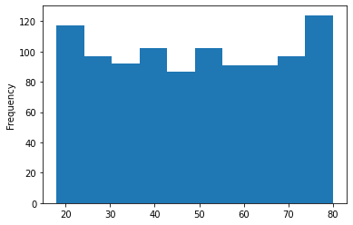

```python
ax = df_union_interna_3['Edad'].plot(kind='hist', x='Edad')
```

notamos que la edad de los trabajadores está equilibrada. Podemos ver la distribución de la edad para el departamento de Seguridad:

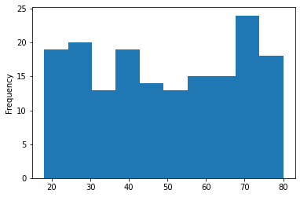

```python
mascara = df_union_interna_3['Dep'] == 'Seguridad'
ax = df_union_interna_3[mascara]['Edad'].plot(kind='hist', x='Edad')
```

- Número de trabajadores por departamento

```python
# en este caso seleccionaremos cualquier columna (['ID'])
df_union_interna_3.groupby('Dep')['ID'].count()
```

```
Dep
Almacen       177
Comedor       173
Limpieza      153
Oficina       171
Seguridad     170
Transporte    156
Name: ID, dtype: int64
```

Notamos que, gracias a la primer unión interna, pudimos obtener resultados y conclusiones referentes a los salarios de los empleados, lo cual muestra la gran utilidad de éstas.

### Tipos de uniones

La única unión que hemos visto hasta el momento es la unión interna. Lo que haremos a continuación será ver otro tipo de uniones.

#### Unión izquierda y derecha

De nuevo, consideremos dos dataframes y veámoslos como conjuntos. Recordemos que la unión interna puede verse como:

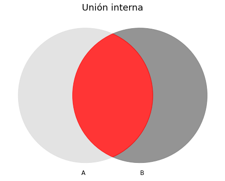

```python
# tamanio (largo por ancho) del grafico
plt.figure(figsize=(8,6))

# diagrama
v = venn2((1,1,1), set_labels=('A', 'B'), alpha=0.8)

# Colores
v.get_patch_by_id('10').set_color('#DCDCDC')
v.get_patch_by_id('11').set_color('#FF0202')
v.get_patch_by_id('01').set_color('#797979')
# Etiquetas
v.get_label_by_id('10').set_text("")
v.get_label_by_id('11').set_text("")
v.get_label_by_id('01').set_text("")

plt.title('Unión interna', size=18)
plt.show()
```

Luego, en la unión izquierda daremos prioridad a los elementos del dataframe de la izquierda (conjunto A), es decir, consideraremos a todos los elementos del conjunto A. Además, consideraremos a los elementos del conjunto B, pero solo a aquellos que se encuentren también en el conjunto A. Gráficamente:

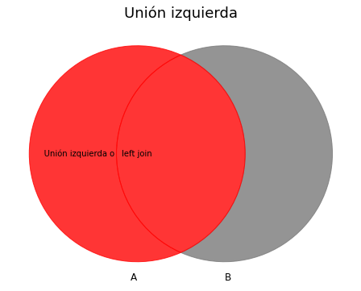

```python
# tamanio (largo por ancho) del grafico
plt.figure(figsize=(8,6))

# diagrama
v = venn2((1,1,1), set_labels=('A', 'B'), alpha=0.8)

# Colores
v.get_patch_by_id('10').set_color('#FF0202')
v.get_patch_by_id('11').set_color('#FF0202')
v.get_patch_by_id('01').set_color('#797979')
# Etiquetas
v.get_label_by_id('10').set_text(" "*5 + "Unión izquierda o")
v.get_label_by_id('11').set_text("left join" + " "*35)
v.get_label_by_id('01').set_text("")

plt.title('Unión izquierda', size=18)
plt.show()
```

A pesar que en el gráfico anterior parece que solo estamos contemplando al conjunto A, recordemos que el conjunto B tiene información adicional, de modo que en la unión izquierda tendremos a los elementos de A y a los de B que también se encuentran en A, pero adicionalmente los elementos de B tiene información que no se encuentra en el conjunto A.

Por ejemplo, recordemos que el dataframe `df_empleados` tiene dos filas más que `df_salario`

```python
print(df_empleados.shape)
print(df_salario.shape)
```

```
(1002, 5)
(1000, 3)
```

Y recordemos que cuando hicimos la unión interna no se consideraron a las dos filas adicionales del dataframe `df_empleados`

```python
df_union_interna.shape
```

```
(1000, 6)
```

Ahora bien, lo que haremos será realizar una unión izquierda entre `df_empleados` y `df_salario`, con lo cual consideramos en la unión a todos los elementos del primer conjunto o primer dataframe, de donde las dos filas extra de `df_empleados` ahora sí serán consideradas en el dataframe resultante de dicha unión. En efecto:

```python
# Union izquierda
df_left_join = df_empleados.merge(df_salario, on='ID',
                                  suffixes=('_personal', '_compañia'),
                                  # Especificamos el tipo
                                  # de union con how=.
                                  # Union izquierda
                                  how='left')
df_left_join.shape
```

```
(1002, 7)
```

```python
# Veamos que
df_left_join.tail()
```

|  | ID | Nombre | Edad | Correo_personal | Dep | Salario | Correo_compañia |
| --- | --- | --- | --- | --- | --- | --- | --- |
| 997 | 998 | Todd Jenkins Anderson | 28 | lisaknight@example.com | Almacen | 2928.811436 | clarkcharles@example.net |
| 998 | 999 | Kimberly Mitchell Long | 65 | ejohnson@example.org | Seguridad | 7046.036444 | jsmith@example.net |
| 999 | 1000 | Andrea Carson Liu | 48 | emilysantos@example.net | Oficina | 7518.045080 | perkinsmonica@example.net |
| 1000 | 1001 | Diana Smith | 27 | diana27182@edu.com | Oficina | NaN | NaN |
| 1001 | 1002 | Luka Ldresh | 20 | lukaecdf@gmail.com | Transporte | NaN | NaN |

Dado que para los dos últimos empleados no tenemos información en el dataframe `df_salario` se ha colocado `NaN` en las columnas `Salario` y `Correo_compañia`. EL punto es que con esta unión daremos prioridad al dataframe de la izquierda.

Gracias a lo anterior podríamos ver cuáles empleados aún no tienen su información registrada en el dataframe `df_salario`.

```python
# Detectamos a los empleados que aun no tienen su informacion
# registrada en el dataframe df_salario
df_left_join[df_left_join.Salario.isnull()][['ID','Nombre']]
```

|  | ID | Nombre |
| --- | --- | --- |
| 1000 | 1001 | Diana Smith |
| 1001 | 1002 | Luka Ldresh |

De manera totalmente análoga tenemos el concepto de unión derecha:

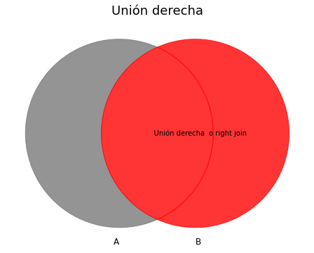

```python
# tamanio (largo por ancho) del grafico
plt.figure(figsize=(8,6))

# diagrama
v = venn2((1,1,1), set_labels=('A', 'B'), alpha=0.8)

# Colores
v.get_patch_by_id('10').set_color('#797979')
v.get_patch_by_id('11').set_color('#FF0202')
v.get_patch_by_id('01').set_color('#FF0202')
# Etiquetas
v.get_label_by_id('10').set_text("")
v.get_label_by_id('11').set_text(" "*20 + "Unión derecha")
v.get_label_by_id('01').set_text(" o right join" + " "*22)

plt.title('Unión derecha', size=18)
plt.show()
```

donde si hicieramos una unión derecha entre `df_empleados` y `df_salario` no se considerarían las dos filas extra de los empleados en la unión, por lo cual el dataframe resultante tendría 1000 filas como el dataframe `df_salario`.

Ahora bien, la columna que relaciona a los dos dataframes puede que tenga distintos nombres. Hasta ahora la columna ha sido `ID`, la cual tiene el mismo nombre en los dataframes `df_empleados` y `df_salario`, pero puede ser que el nombre no sea el mismo. Por ejemplo, cambiemos el nombre de `ID` del dataframe `df_salario` por `Id_s`:

```python
df_salario = df_salario.rename(columns={'ID': 'ID_s'})
df_salario.head()
```

|  | ID_s | Salario | Correo |
| --- | --- | --- | --- |
| 0 | 1 | 2815.715914 | bmora@example.com |
| 1 | 2 | 8071.241496 | sandrathompson@example.org |
| 2 | 3 | 1406.213853 | gibsonkevin@example.net |
| 3 | 4 | 8799.843576 | iharris@example.net |
| 4 | 5 | 3627.843246 | qreynolds@example.com |

Luego, hagamos una unión derecha como sigue

```python
# Union derecha
df_right_join = df_empleados.merge(df_salario, suffixes=('_personal', '_compañia'),
                                   # Especificamos el tipo
                                   # de union con how=.
                                   # Union derecha
                                   how='right',
                                   # (**)
                                   left_on='ID', right_on='ID_s')
df_right_join.head()
```

|  | ID | Nombre | Edad | Correo_personal | Dep | ID_s | Salario | Correo_compañia |
| --- | --- | --- | --- | --- | --- | --- | --- | --- |
| 0 | 1 | Mark Rodriguez Park | 66 | listephanie@example.net | Transporte | 1 | 2815.715914 | bmora@example.com |
| 1 | 2 | Maria Patrick Foley | 58 | annawright@example.net | Transporte | 2 | 8071.241496 | sandrathompson@example.org |
| 2 | 3 | Olivia Boyle King | 18 | alexander11@example.org | Oficina | 3 | 1406.213853 | gibsonkevin@example.net |
| 3 | 4 | Kent Lloyd Thomas | 72 | rroberts@example.org | Comedor | 4 | 8799.843576 | iharris@example.net |
| 4 | 5 | Connie Villa Meyer | 28 | micheal66@example.org | Transporte | 5 | 3627.843246 | qreynolds@example.com |

```python
df_right_join.shape
```

```
(1000, 8)
```

$(**)$: donde `left_on` y `right_on` nos permiten especificar a la unión la columna que relaciona a los dataframes. Tenemos que `left_on` es para especificar el nombre de la columna para el dataframe de la izquierda y `right_on` para el de la derecha. Cabe mencionar que, a pesar que los nombres de la columna de relación son distintos, esencialemente dichas columnas deben ser las mismas en el sentido del tipo de datos que almacenan y, justamente, la información que guardan, aunque como vemos en el ejemplo anterior, las columnas `ID` y `ID_s` no son exactamente iguales pues `ID` tiene dos elementos más que `ID_s`.

#### Unión externa

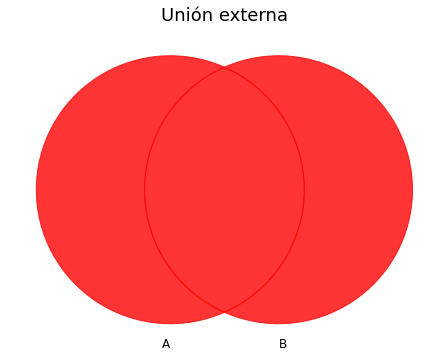

```python
# tamanio (largo por ancho) del grafico
plt.figure(figsize=(8,6))

# diagrama
v = venn2((1,1,1), set_labels=('A', 'B'), alpha=0.8)

# Colores
v.get_patch_by_id('10').set_color('#FF0202')
v.get_patch_by_id('11').set_color('#FF0202')
v.get_patch_by_id('01').set_color('#FF0202')
# Etiquetas
v.get_label_by_id('10').set_text("")
v.get_label_by_id('11').set_text("")
v.get_label_by_id('01').set_text("")

plt.title('Unión externa', size=18)
plt.show()
```

La unión externa (*outer join*) es una unión propiamente conjuntista, es decir, la unión entre dos conjuntos coincide con ser una unión externa, donde todos los elementos de los conjuntos A y B son contemplados.

Básicamente puede entenderse como una unión izquierda y una derecha en simultáneo entre los dataframes involucrados. Antes de ver un ejemplo de unión externa veamos que:

```python
# agregamos un nuevo departamento a df_dep
df_dep = df_dep.append({'Dep': 'Proveedores', 'Salario_min': 8000},
                        ignore_index=True)
df_dep
```

|  | Dep | Salario_min |
| --- | --- | --- |
| 0 | Seguridad | 8000 |
| 1 | Oficina | 8000 |
| 2 | Almacen | 7000 |
| 3 | Limpieza | 6500 |
| 4 | Comedor | 6500 |
| 5 | Transporte | 7000 |
| 6 | Proveedores | 8000 |

de modo que ningún empleado de `df_empleados` trabaja, por ahora, en el nuevo departamento. Luego, agreguemos un nuevo empleado sin colocar departamento:

```python
# empleado nuevo
emp3 = {'ID': 1003, 'Nombre': 'Donovan Cabello', 'Edad': 35, 'Correo': 'donovan31416@edu.com'}
# agregamos al dataframe
df_empleados = df_empleados.append(emp3, ignore_index=True)
```

Por otro lado

```python
# Hacemos una union izquierda entre df_empleados y df_dep
df_left_join = df_empleados.merge(df_dep, on='Dep', how='left')
df_left_join.head()
```

|  | ID | Nombre | Edad | Correo | Dep | Salario_min |
| --- | --- | --- | --- | --- | --- | --- |
| 0 | 1 | Mark Rodriguez Park | 66 | listephanie@example.net | Transporte | 7000.0 |
| 1 | 2 | Maria Patrick Foley | 58 | annawright@example.net | Transporte | 7000.0 |
| 2 | 3 | Olivia Boyle King | 18 | alexander11@example.org | Oficina | 8000.0 |
| 3 | 4 | Kent Lloyd Thomas | 72 | rroberts@example.org | Comedor | 6500.0 |
| 4 | 5 | Connie Villa Meyer | 28 | micheal66@example.org | Transporte | 7000.0 |

```python
df_left_join.shape
```

```
(1003, 6)
```

donde dimos prioridad al dataframe de la izquierda:

```python
df_left_join.tail()
```

|  | ID | Nombre | Edad | Correo | Dep | Salario_min |
| --- | --- | --- | --- | --- | --- | --- |
| 998 | 999 | Kimberly Mitchell Long | 65 | ejohnson@example.org | Seguridad | 8000.0 |
| 999 | 1000 | Andrea Carson Liu | 48 | emilysantos@example.net | Oficina | 8000.0 |
| 1000 | 1001 | Diana Smith | 27 | diana27182@edu.com | Oficina | 8000.0 |
| 1001 | 1002 | Luka Ldresh | 20 | lukaecdf@gmail.com | Transporte | 7000.0 |
| 1002 | 1003 | Donovan Cabello | 35 | donovan31416@edu.com | NaN | NaN |

Luego

```python
# Hacemos una union derecha entre df_empleados y df_dep
df_right_join = df_empleados.merge(df_dep, on='Dep', how='right')
df_right_join.head()
```

|  | ID | Nombre | Edad | Correo | Dep | Salario_min |
| --- | --- | --- | --- | --- | --- | --- |
| 0 | 6.0 | Mary Pierce Craig | 54.0 | smithveronica@example.com | Seguridad | 8000 |
| 1 | 21.0 | Michael Ellis Crawford | 30.0 | ellen04@example.net | Seguridad | 8000 |
| 2 | 24.0 | Kenneth Fisher Perez | 18.0 | christineclements@example.net | Seguridad | 8000 |
| 3 | 29.0 | Benjamin Rivera Mcmillan | 57.0 | jcochran@example.com | Seguridad | 8000 |
| 4 | 32.0 | Kristin White Watson | 78.0 | bowenmark@example.net | Seguridad | 8000 |

```python
df_right_join.shape
```

```
(1003, 6)
```

```python
df_right_join.tail()
```

|  | ID | Nombre | Edad | Correo | Dep | Salario_min |
| --- | --- | --- | --- | --- | --- | --- |
| 998 | 982.0 | Andrew Alexander Giles | 69.0 | watsontyler@example.net | Transporte | 7000 |
| 999 | 994.0 | Omar Hill Sullivan | 75.0 | tyler50@example.net | Transporte | 7000 |
| 1000 | 995.0 | Kyle Palmer Ortiz | 44.0 | walterheidi@example.net | Transporte | 7000 |
| 1001 | 1002.0 | Luka Ldresh | 20.0 | lukaecdf@gmail.com | Transporte | 7000 |
| 1002 | NaN | NaN | NaN | NaN | Proveedores | 8000 |

donde dimos prioridad al dataframe de la derecha, además, notamos que el último empleado que agregamos al dataframe `df_empleados` no es considerado en la unión derecha.

Finalmente, apliquemos una unión externa:

```python
# Union externa
df_outer_join = df_empleados.merge(df_dep, on='Dep', how='outer')
df_outer_join.head()
```

|  | ID | Nombre | Edad | Correo | Dep | Salario_min |
| --- | --- | --- | --- | --- | --- | --- |
| 0 | 1.0 | Mark Rodriguez Park | 66.0 | listephanie@example.net | Transporte | 7000.0 |
| 1 | 2.0 | Maria Patrick Foley | 58.0 | annawright@example.net | Transporte | 7000.0 |
| 2 | 5.0 | Connie Villa Meyer | 28.0 | micheal66@example.org | Transporte | 7000.0 |
| 3 | 22.0 | Mary Payne Johnson | 18.0 | rdiaz@example.com | Transporte | 7000.0 |
| 4 | 36.0 | Michael Owens Burns | 27.0 | ypowell@example.net | Transporte | 7000.0 |

```python
df_outer_join.shape
```

```
(1004, 6)
```

```python
df_outer_join.tail()
```

|  | ID | Nombre | Edad | Correo | Dep | Salario_min |
| --- | --- | --- | --- | --- | --- | --- |
| 999 | 990.0 | Jordan Jackson Higgins | 56.0 | lewisstephen@example.net | Almacen | 7000.0 |
| 1000 | 992.0 | Sara Rodgers Mitchell | 60.0 | xkrause@example.com | Almacen | 7000.0 |
| 1001 | 998.0 | Todd Jenkins Anderson | 28.0 | lisaknight@example.com | Almacen | 7000.0 |
| 1002 | 1003.0 | Donovan Cabello | 35.0 | donovan31416@edu.com | NaN | NaN |
| 1003 | NaN | NaN | NaN | NaN | Proveedores | 8000.0 |

Vemos que en la unión externa todos los elementos de ambos dataframes fueron considerados.

Gracias al outer join podemos identificar a los elementos que solo están en el dataframe A o que solo están en el dataframe B, es decir, omitimos los elementos que están en A y B. Gráficamente

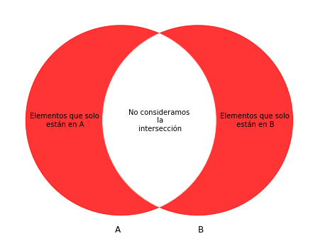

```python
# tamanio (largo por ancho) del grafico
plt.figure(figsize=(8,6))

# diagrama
v = venn2((1,1,1), set_labels=('A', 'B'), alpha=0.8)

# Colores
v.get_patch_by_id('10').set_color('#FF0202')
v.get_patch_by_id('11').set_color('#FFFFFF')
v.get_patch_by_id('01').set_color('#FF0202')
# Etiquetas
v.get_label_by_id('10').set_text("Elementos que solo\n están en A")
v.get_label_by_id('11').set_text("No consideramos\n la\n intersección")
v.get_label_by_id('01').set_text("Elementos que solo\n están en B")

plt.show()
```

Por ejemplo a partir de la unión externa que realizamos antes podemos hallar a los empleados a los cuales aún no se les asigna departamento, asimismo, hallar los departamentos que aún no tienen empleado (¡Sí!, es un ejemplo bobo (¿qué miras bobo?) pero ilustrativo).

Para ello

```python
# obtenemos los elementos que tienen valores nulos en ID,
# lo cual nos dara los departamentos que aun no tiene empleados.
# Obtenemos los elementos que tienen valores nulos en Dep,
# lo cual nos dara los empleados que aun no tienen
# departamento asignado
mask = (df_outer_join['ID'].isnull()) | (df_outer_join['Dep'].isnull())

# Pasamos la mascara al dataframe de la union externa
df_outer_join[mask][['Nombre', 'Dep']]
```

|  | Nombre | Dep |
| --- | --- | --- |
| 1002 | Donovan Cabello | NaN |
| 1003 | NaN | Proveedores |

#### Uniendo una tabla con ella misma

```python
# recordemos que tenemos los distintos departamentes
# almacenados en una lista
dep
```

```
['Seguridad', 'Oficina', 'Almacen', 'Limpieza', 'Comedor', 'Transporte']
```

```python
df_empleados[df_empleados.Dep == i].sample(5)
```

|  | ID | Nombre | Edad | Correo | Dep |
| --- | --- | --- | --- | --- | --- |
| 734 | 735 | Lori Spears Stokes | 54 | cmccarthy@example.net | Transporte |
| 97 | 98 | Andrew Mora Collins | 35 | lisamiller@example.org | Transporte |
| 445 | 446 | Katherine Rowland Austin | 56 | garrettrodney@example.net | Transporte |
| 885 | 886 | Jason Robinson Bennett | 31 | gbarrera@example.net | Transporte |
| 67 | 68 | Tiffany Phillips Smith | 70 | tlawson@example.com | Transporte |

```python
# Luego, obtenemos dos empleados (sus ID's) de manera aleatoria
# por departamento y agregamos sus ID's a una lista vacia
sup = []
for i in range(2):
    for i in dep:
        id_empleado_select = df_empleados[df_empleados.Dep == i].sample(10).iloc[0][0]
        print(f'{i}. ID: {id_empleado_select}')
        sup.append((id_empleado_select, i))
```

```
Seguridad. ID: 652
Oficina. ID: 790
Almacen. ID: 992
Limpieza. ID: 10
Comedor. ID: 383
Transporte. ID: 734
Seguridad. ID: 182
Oficina. ID: 23
Almacen. ID: 739
Limpieza. ID: 386
Comedor. ID: 58
Transporte. ID: 995
```

```python
# lista con los ID's de los empleados seleccionados por
# departamento
sup
```

```
[(652, 'Seguridad'),
 (790, 'Oficina'),
 (992, 'Almacen'),
 (10, 'Limpieza'),
 (383, 'Comedor'),
 (734, 'Transporte'),
 (182, 'Seguridad'),
 (23, 'Oficina'),
 (739, 'Almacen'),
 (386, 'Limpieza'),
 (58, 'Comedor'),
 (995, 'Transporte')]
```

Lo que haremos es que los empleados seleccionados anteriormente serán supervisores de sus respectivos departamentos, luego, a cada uno de los empleados les asignaremos un supervisor y dicha información la agregaremos al dataframe `df_empleados`. Así

```python
# ID de los de Seguridad
print(sup[0][0])
print(sup[6][0])
# ID de los de Oficina
print(sup[1][0])
print(sup[7][0])
# ID de los de Almacen
print(sup[2][0])
print(sup[8][0])
# ID de los de Limpieza
print(sup[3][0])
print(sup[9][0])
# ID de los de Comedor
print(sup[4][0])
print(sup[10][0])
# ID de los de Transporte
print(sup[5][0])
print(sup[11][0])
```

```
652
182
790
23
992
739
10
386
383
58
734
995
```

```python
# Dependiendo del departamento del empleado,
# le asignaremos (de manera aleatoria) el ID de un supervisor
# del mismo departamento. Dichos ID los almacenamos
# en la siguiente lista
supervisor = []
for i in range(df_empleados.shape[0]):
    if df_empleados.iloc[i][4] == 'Seguridad':
        supervisor.append(random.choice([sup[0][0], sup[6][0]]))
    elif df_empleados.iloc[i][4] == 'Oficina':
        supervisor.append(random.choice([sup[1][0], sup[7][0]]))
    elif df_empleados.iloc[i][4] == 'Almacen':
        supervisor.append(random.choice([sup[2][0], sup[8][0]]))
    elif df_empleados.iloc[i][4] == 'Limpieza':
        supervisor.append(random.choice([sup[3][0], sup[9][0]]))
    elif df_empleados.iloc[i][4] == 'Comedor':
        supervisor.append(random.choice([sup[4][0], sup[10][0]]))
    else:
        supervisor.append(random.choice([sup[5][0], sup[11][0]]))

# Agregamos la columna nueva
df_empleados['Sup'] = supervisor
df_empleados.head()
```

|  | ID | Nombre | Edad | Correo | Dep | Sup |
| --- | --- | --- | --- | --- | --- | --- |
| 0 | 1 | Mark Rodriguez Park | 66 | listephanie@example.net | Transporte | 995 |
| 1 | 2 | Maria Patrick Foley | 58 | annawright@example.net | Transporte | 995 |
| 2 | 3 | Olivia Boyle King | 18 | alexander11@example.org | Oficina | 790 |
| 3 | 4 | Kent Lloyd Thomas | 72 | rroberts@example.org | Comedor | 383 |
| 4 | 5 | Connie Villa Meyer | 28 | micheal66@example.org | Transporte | 995 |

Ahora sí, con la información que tenemos podemos hacer un autojoin de modo que podamos ver el departamento al cual pertenece cada supervisor, lo cual conseguiremos gracias a que el `ID` y la columna `Sup` están relacionadas. Así, realizamos el autojoin considerando en `left_on=` la columna `Sup` y `right_on=` la columna `ID` pues querremos ligar los ID's de `Sup` con los ID's generales de la columna `ID` (puedes probar configurando `left_on='ID'` y `right_on='Sup'` y ver qué es lo que pasa).

```python
df_self_join = df_empleados.merge(df_empleados,
                                  left_on='Sup',
                                  right_on='ID',
                                  suffixes=('_df1', '_df2'))
df_self_join
```

|  | ID_df1 | Nombre_df1 | Edad_df1 | Correo_df1 | Dep_df1 | Sup_df1 | ID_df2 | Nombre_df2 | Edad_df2 | Correo_df2 | Dep_df2 | Sup_df2 |
| --- | --- | --- | --- | --- | --- | --- | --- | --- | --- | --- | --- | --- |
| 0 | 1 | Mark Rodriguez Park | 66 | listephanie@example.net | Transporte | 995 | 995 | Kyle Palmer Ortiz | 44 | walterheidi@example.net | Transporte | 734 |
| 1 | 2 | Maria Patrick Foley | 58 | annawright@example.net | Transporte | 995 | 995 | Kyle Palmer Ortiz | 44 | walterheidi@example.net | Transporte | 734 |
| 2 | 5 | Connie Villa Meyer | 28 | micheal66@example.org | Transporte | 995 | 995 | Kyle Palmer Ortiz | 44 | walterheidi@example.net | Transporte | 734 |
| 3 | 22 | Mary Payne Johnson | 18 | rdiaz@example.com | Transporte | 995 | 995 | Kyle Palmer Ortiz | 44 | walterheidi@example.net | Transporte | 734 |
| 4 | 39 | Jesse Wells Johnson | 64 | mmorgan@example.com | Transporte | 995 | 995 | Kyle Palmer Ortiz | 44 | walterheidi@example.net | Transporte | 734 |
| ... | ... | ... | ... | ... | ... | ... | ... | ... | ... | ... | ... | ... |
| 998 | 934 | Scott Clark Barnes | 19 | hwilson@example.net | Almacen | 992 | 992 | Sara Rodgers Mitchell | 60 | xkrause@example.com | Almacen | 739 |
| 999 | 941 | Thomas Werner Brown | 57 | michelle11@example.net | Almacen | 992 | 992 | Sara Rodgers Mitchell | 60 | xkrause@example.com | Almacen | 739 |
| 1000 | 955 | Carlos Meyer Sullivan | 66 | yferguson@example.org | Almacen | 992 | 992 | Sara Rodgers Mitchell | 60 | xkrause@example.com | Almacen | 739 |
| 1001 | 956 | Daniel Gibson Jenkins | 27 | vcook@example.net | Almacen | 992 | 992 | Sara Rodgers Mitchell | 60 | xkrause@example.com | Almacen | 739 |
| 1002 | 990 | Jordan Jackson Higgins | 56 | lewisstephen@example.net | Almacen | 992 | 992 | Sara Rodgers Mitchell | 60 | xkrause@example.com | Almacen | 739 |

1003 rows × 12 columns

```python
# Seleccionamos solo una columnas para ver de mejor manera la informacion
df_self_join.iloc[:,[0,1,4,5,6,7,8,9,10]]
```

|  | ID_df1 | Nombre_df1 | Dep_df1 | Sup_df1 | ID_df2 | Nombre_df2 | Edad_df2 | Correo_df2 | Dep_df2 |
| --- | --- | --- | --- | --- | --- | --- | --- | --- | --- |
| 0 | 1 | Mark Rodriguez Park | Transporte | 995 | 995 | Kyle Palmer Ortiz | 44 | walterheidi@example.net | Transporte |
| 1 | 2 | Maria Patrick Foley | Transporte | 995 | 995 | Kyle Palmer Ortiz | 44 | walterheidi@example.net | Transporte |
| 2 | 5 | Connie Villa Meyer | Transporte | 995 | 995 | Kyle Palmer Ortiz | 44 | walterheidi@example.net | Transporte |
| 3 | 22 | Mary Payne Johnson | Transporte | 995 | 995 | Kyle Palmer Ortiz | 44 | walterheidi@example.net | Transporte |
| 4 | 39 | Jesse Wells Johnson | Transporte | 995 | 995 | Kyle Palmer Ortiz | 44 | walterheidi@example.net | Transporte |
| ... | ... | ... | ... | ... | ... | ... | ... | ... | ... |
| 998 | 934 | Scott Clark Barnes | Almacen | 992 | 992 | Sara Rodgers Mitchell | 60 | xkrause@example.com | Almacen |
| 999 | 941 | Thomas Werner Brown | Almacen | 992 | 992 | Sara Rodgers Mitchell | 60 | xkrause@example.com | Almacen |
| 1000 | 955 | Carlos Meyer Sullivan | Almacen | 992 | 992 | Sara Rodgers Mitchell | 60 | xkrause@example.com | Almacen |
| 1001 | 956 | Daniel Gibson Jenkins | Almacen | 992 | 992 | Sara Rodgers Mitchell | 60 | xkrause@example.com | Almacen |
| 1002 | 990 | Jordan Jackson Higgins | Almacen | 992 | 992 | Sara Rodgers Mitchell | 60 | xkrause@example.com | Almacen |

1003 rows × 9 columns

con lo cual obtenemos lo que buscábamos, es decir, logramos ver a qué departamente pertenece cada supervisor. Veamos cuántas personas dirige cada supervisor, para lo cual agruparemos por nombre del supervisor y departamento, luego seleccionamos cualquier columna, digamos `ID_df1` y finalmente realizamos el conteo:

```python
df_self_join.groupby(['Nombre_df2', 'Dep_df2'])['ID_df1'].count()
```

```
Nombre_df2                  Dep_df2
Cheyenne Brown Jones        Oficina       98
Cynthia Martin Jones        Almacen       86
Erik Sanchez III Turner     Limpieza      68
Harry Coleman Phelps        Comedor       88
Jessica Cooper Pierce       Transporte    76
Karen Harding Warren        Seguridad     85
Kyle Palmer Ortiz           Transporte    82
Megan Woods Snow            Oficina       74
Michael Carroll PhD Jordan  Limpieza      85
Samuel Terry Boyer          Seguridad     85
Sara Rodgers Mitchell       Almacen       91
Steven Price Hall           Comedor       85
Name: ID_df1, dtype: int64
```

Por otro lado, notemos del dataframe que:

```python
df_self_join.iloc[:,[0,1,4,5,7,8,10,-1]]
```

|  | ID_df1 | Nombre_df1 | Dep_df1 | Sup_df1 | Nombre_df2 | Edad_df2 | Dep_df2 | Sup_df2 |
| --- | --- | --- | --- | --- | --- | --- | --- | --- |
| 0 | 1 | Mark Rodriguez Park | Transporte | 995 | Kyle Palmer Ortiz | 44 | Transporte | 734 |
| 1 | 2 | Maria Patrick Foley | Transporte | 995 | Kyle Palmer Ortiz | 44 | Transporte | 734 |
| 2 | 5 | Connie Villa Meyer | Transporte | 995 | Kyle Palmer Ortiz | 44 | Transporte | 734 |
| 3 | 22 | Mary Payne Johnson | Transporte | 995 | Kyle Palmer Ortiz | 44 | Transporte | 734 |
| 4 | 39 | Jesse Wells Johnson | Transporte | 995 | Kyle Palmer Ortiz | 44 | Transporte | 734 |
| ... | ... | ... | ... | ... | ... | ... | ... | ... |
| 998 | 934 | Scott Clark Barnes | Almacen | 992 | Sara Rodgers Mitchell | 60 | Almacen | 739 |
| 999 | 941 | Thomas Werner Brown | Almacen | 992 | Sara Rodgers Mitchell | 60 | Almacen | 739 |
| 1000 | 955 | Carlos Meyer Sullivan | Almacen | 992 | Sara Rodgers Mitchell | 60 | Almacen | 739 |
| 1001 | 956 | Daniel Gibson Jenkins | Almacen | 992 | Sara Rodgers Mitchell | 60 | Almacen | 739 |
| 1002 | 990 | Jordan Jackson Higgins | Almacen | 992 | Sara Rodgers Mitchell | 60 | Almacen | 739 |

1003 rows × 8 columns

Cada supervisor tiene, nuevamente, un supervisor. Por ejemplo, para la empleada `Kyle Palmer Ortiz`, su supervisor tiene el ID (`Sup_df2`) de 734

```python
df_empleados[df_empleados.ID == 734]
```

|  | ID | Nombre | Edad | Correo | Dep | Sup |
| --- | --- | --- | --- | --- | --- | --- |
| 733 | 734 | Jessica Cooper Pierce | 57 | brucejennifer@example.net | Transporte | 995 |

De tal manera, podemos hacer una unión entre `df_self_join` y `df_empleados` para obtener los supervisores de los supervisores. Para ello realizaremos una unión izquierda, debido a que queremos priorizar los ID's (o elementos) referentes al dataframe `df_self_join`

```python
df_left_join = df_self_join.merge(df_empleados, how='left',
                                  left_on='Sup_df2',
                                  right_on='ID')
df_left_join
```

|  | ID_df1 | Nombre_df1 | Edad_df1 | Correo_df1 | Dep_df1 | Sup_df1 | ID_df2 | Nombre_df2 | Edad_df2 | Correo_df2 | Dep_df2 | Sup_df2 | ID | Nombre | Edad | Correo | Dep | Sup |
| --- | --- | --- | --- | --- | --- | --- | --- | --- | --- | --- | --- | --- | --- | --- | --- | --- | --- | --- |
| 0 | 1 | Mark Rodriguez Park | 66 | listephanie@example.net | Transporte | 995 | 995 | Kyle Palmer Ortiz | 44 | walterheidi@example.net | Transporte | 734 | 734 | Jessica Cooper Pierce | 57 | brucejennifer@example.net | Transporte | 995 |
| 1 | 2 | Maria Patrick Foley | 58 | annawright@example.net | Transporte | 995 | 995 | Kyle Palmer Ortiz | 44 | walterheidi@example.net | Transporte | 734 | 734 | Jessica Cooper Pierce | 57 | brucejennifer@example.net | Transporte | 995 |
| 2 | 5 | Connie Villa Meyer | 28 | micheal66@example.org | Transporte | 995 | 995 | Kyle Palmer Ortiz | 44 | walterheidi@example.net | Transporte | 734 | 734 | Jessica Cooper Pierce | 57 | brucejennifer@example.net | Transporte | 995 |
| 3 | 22 | Mary Payne Johnson | 18 | rdiaz@example.com | Transporte | 995 | 995 | Kyle Palmer Ortiz | 44 | walterheidi@example.net | Transporte | 734 | 734 | Jessica Cooper Pierce | 57 | brucejennifer@example.net | Transporte | 995 |
| 4 | 39 | Jesse Wells Johnson | 64 | mmorgan@example.com | Transporte | 995 | 995 | Kyle Palmer Ortiz | 44 | walterheidi@example.net | Transporte | 734 | 734 | Jessica Cooper Pierce | 57 | brucejennifer@example.net | Transporte | 995 |
| ... | ... | ... | ... | ... | ... | ... | ... | ... | ... | ... | ... | ... | ... | ... | ... | ... | ... | ... |
| 998 | 934 | Scott Clark Barnes | 19 | hwilson@example.net | Almacen | 992 | 992 | Sara Rodgers Mitchell | 60 | xkrause@example.com | Almacen | 739 | 739 | Cynthia Martin Jones | 58 | bowmankara@example.com | Almacen | 992 |
| 999 | 941 | Thomas Werner Brown | 57 | michelle11@example.net | Almacen | 992 | 992 | Sara Rodgers Mitchell | 60 | xkrause@example.com | Almacen | 739 | 739 | Cynthia Martin Jones | 58 | bowmankara@example.com | Almacen | 992 |
| 1000 | 955 | Carlos Meyer Sullivan | 66 | yferguson@example.org | Almacen | 992 | 992 | Sara Rodgers Mitchell | 60 | xkrause@example.com | Almacen | 739 | 739 | Cynthia Martin Jones | 58 | bowmankara@example.com | Almacen | 992 |
| 1001 | 956 | Daniel Gibson Jenkins | 27 | vcook@example.net | Almacen | 992 | 992 | Sara Rodgers Mitchell | 60 | xkrause@example.com | Almacen | 739 | 739 | Cynthia Martin Jones | 58 | bowmankara@example.com | Almacen | 992 |
| 1002 | 990 | Jordan Jackson Higgins | 56 | lewisstephen@example.net | Almacen | 992 | 992 | Sara Rodgers Mitchell | 60 | xkrause@example.com | Almacen | 739 | 739 | Cynthia Martin Jones | 58 | bowmankara@example.com | Almacen | 992 |

1003 rows × 18 columns

Luego, veamos cuántos empleados están bajo el mando de cada supervisor por departamento:

```python
df_left_join.groupby(['Nombre', 'Dep'])['ID'].count()
```

```
Nombre                   Dep
Cheyenne Brown Jones     Oficina        98
Cynthia Martin Jones     Almacen        91
Erik Sanchez III Turner  Limpieza      153
Jessica Cooper Pierce    Transporte     82
Karen Harding Warren     Seguridad     170
Kyle Palmer Ortiz        Transporte     76
Megan Woods Snow         Oficina        74
Sara Rodgers Mitchell    Almacen        86
Steven Price Hall        Comedor       173
Name: ID, dtype: int64
```

En comparación con el primer nivel de supervisores

```python
df_left_join.groupby(['Nombre_df2', 'Dep_df2'])['ID_df1'].count()
```

```
Nombre_df2                  Dep_df2
Cheyenne Brown Jones        Oficina       98
Cynthia Martin Jones        Almacen       86
Erik Sanchez III Turner     Limpieza      68
Harry Coleman Phelps        Comedor       88
Jessica Cooper Pierce       Transporte    76
Karen Harding Warren        Seguridad     85
Kyle Palmer Ortiz           Transporte    82
Megan Woods Snow            Oficina       74
Michael Carroll PhD Jordan  Limpieza      85
Samuel Terry Boyer          Seguridad     85
Sara Rodgers Mitchell       Almacen       91
Steven Price Hall           Comedor       85
Name: ID_df1, dtype: int64
```

#### Exportando dataframe a csv

Los dataframes de pandas los podemos exportar como archivos, en particular, csv. Así, lo que haremos será exportar a csv los dataframes `df_empleados, df_salario, df_dep` utilizando la función `to_csv()` como sigue

```python
# colocamos dentro del parentesis el nombre del archivo
# que le queremos dar
df_empleados.to_csv('Empleados.csv')
```

```python
# Hacemos lo mismo con el resto de dataframes
df_salario.to_csv('Salario.csv')
df_dep.to_csv('Departamentos.csv')
```

Con lo hecho anteriormente podremos acceder a los dataframes anteriores desde otras notebooks. Por ejemplo, podemos cargar el archivo `Salario.csv` como ya sabemos

```python
df = pd.read_csv('Salario.csv')
df
```

|  | Unnamed: 0 | ID_s | Salario | Correo |
| --- | --- | --- | --- | --- |
| 0 | 0 | 1 | 2815.715914 | bmora@example.com |
| 1 | 1 | 2 | 8071.241496 | sandrathompson@example.org |
| 2 | 2 | 3 | 1406.213853 | gibsonkevin@example.net |
| 3 | 3 | 4 | 8799.843576 | iharris@example.net |
| 4 | 4 | 5 | 3627.843246 | qreynolds@example.com |
| ... | ... | ... | ... | ... |
| 995 | 995 | 996 | 7529.199265 | xbanks@example.org |
| 996 | 996 | 997 | 904.769353 | jamestyler@example.org |
| 997 | 997 | 998 | 2928.811436 | clarkcharles@example.net |
| 998 | 998 | 999 | 7046.036444 | jsmith@example.net |
| 999 | 999 | 1000 | 7518.045080 | perkinsmonica@example.net |

1000 rows × 4 columns